# Clustering, dimensionality reduction and pseudotime calculation

Janine Melsen

08/04/2020

In this markdown document, we will demonstrate how you can calculate clusters, perform dimensionality reduction, and infer cellular trajectories (pseudotime).

As input, we load the fcs files containing the HSNE-based CD4 clusters (as exported from Cytosplore). We will perform alternative clustering methods (flowsom, phenograph), and alternative dimensionality reduction methods (umap, diffusion map) Lastly, we infer a cellular trajectory by Slingshot. The output of this markdown document is a csv file containing all the above information, including the expression values of each cell. By running this markdown document the df.csv file on the GitHub repository can be reproduced.

This csv file can be used for further visulization purposes, as described in the visualization markdown.

## Load packages

```r
library(flowCore)
library(FlowSOM)
library(SingleCellExperiment)
library(dplyr)
library(ggplot2)
library(scales)
library(reshape2)
library(RColorBrewer)
library(destiny)
library(uwot)
library(slingshot)
library(cytofkit2)
library(ggrepel)
```

## Load data

Load the (transformed, normalized, unclustered) FCS files from the ‘CSV_to_transformed_normalized_FCS’ R script or load fcs files which where clustered in Cytosplore (in this case each fcs file is 1 cluster).

Here, we load the clustered fcs files (as stored in the ‘HSNE_clusters_CD4’ folder)

Provide the directory of the fcs files

```r
dirFCS = '//vf-d3-home/d3home$/jemelsen/MyDocs/GitHub/Single-cell-analysis-flow-cytometry/HSNE_clusters_CD4'
```

Optional: when loading clustered fcs files from cytosplore, provide the directory of the text file ‘CSPLR_ST.txt’. Cytosplore exports this file upon running the HSNE. This file contains the decoding of the sample numbers to the original file name

```r
pathST = '//vf-d3-home/d3home$/jemelsen/MyDocs/GitHub/Single-cell-analysis-flow-cytometry/HSNE_clusters_CD4/CSPLR_ST.txt'
```

Define a function to read multiple fcs files from a directory ‘dir’ into a single data.frame: NB: The column in the output named ‘fileName’ tracks the original file where each cell came from.

```r
read.flowdat <- function(dir,path_CSPLR_ST=""){
  # Read:
  filepaths <- list.files(path=dir,pattern = ".fcs", full.names=TRUE)
  flowset <- read.flowSet(files=filepaths, transformation=FALSE, truncate_max_range = FALSE)
  # Transform to data frame:
  x <- as.data.frame(exprs(as(flowset,'flowFrame')),stringsAsFactors=FALSE)
  # Map column 'Original' to filename (in this case holding clusters of HSNE):
  filenames <- gsub("[.fcs]","",list.files(path=dir,pattern = ".fcs", full.names=FALSE))
  names(filenames) <- sort(unique(x$Original))
  x$fileName <- filenames[as.character(x$Original)]
  # Remove column 'Original':
  x <- x[,-which(colnames(x)=="Original")]
  # Optionally remap Cytosplore sample tags to original filename:
  if(file.exists(path_CSPLR_ST)){
    # Read:
    sampID <- gsub(".fcs","",basename(sapply(strsplit(readLines(path_CSPLR_ST),": "),function(x) x[1])))
    names(sampID) <- sapply(strsplit(readLines(path_CSPLR_ST),": "),function(x) x[2])
    x$sampleID <- sampID[as.character(x$CSPLR_ST)]
  }
  return(x)
}
```

Read fcs files Optionally: perform remapping of sampletag ‘CSPLR-ST’ to original file name

```r
df <- read.flowdat(dir=dirFCS,path_CSPLR_ST = pathST)
```

```r
head(df)
```

```
##      FSC.A  FSC.H    FSC.W    SSC.A SSC.H    SSC.W        CD95         CD8
## 1 123725.3 114537 70793.39 29916.04 29725 65957.20  0.04919554 -0.04211360
## 2 129744.8 113527 74898.12 37344.06 35011 69903.19  0.06008087 -0.07160002
## 3 134425.1 122187 72100.02 29106.00 28719 66419.13 -0.08300304 -0.05722039
## 4 129715.4 117286 72481.21 38762.57 36082 70404.73  0.02296851 -0.22416283
## 5 135594.0 118113 75235.51 36312.43 34373 69233.75 -0.06238258  0.07444189
## 6 109618.7  98183 73169.21 24938.76 24099 67819.69  0.18458755  0.09685653
##       CD27      CXCR4     CCR7 LIVE.DEAD      CD4   CD45RA      CD3       CD49b
## 1 2.043456 -154.76010 1.617012 418.72021 1.115082 1.509235 2.494015 -0.15329744
## 2 1.899140  -55.10397 1.295678  62.95781 1.473094 1.649236 2.228497  0.13627116
## 3 2.095128 -138.39290 1.184099 773.71948 1.358547 1.497685 2.266846  0.04310955
## 4 1.978630   66.90539 1.450845 194.00330 1.453925 1.691411 2.390522  0.09496491
## 5 2.137328   88.51750 1.517236 244.99280 1.276686 1.428678 2.169388 -0.07254910
## 6 2.151697  -25.66885 1.486741 778.22522 1.317697 1.639596 2.038711 -0.06887352
##      CD14.19         CD69       CD103   TIME    CD95_150     CD8_150 CD27_150
```

[output cut: 20 more lines]

Optional: in case you loaded the clustered fcsfiles, the filename refers to the cluster. Therefore we change the column name ‘fileName’ to ‘clusters_HSNE’

```r
colnames(df)[which(colnames(df)=="fileName")] <- "clusters_HSNE"
```

In our example we just loaded the 275856 CD4 T cells, as clustered by HSNE-based gaussian mean shift clustering in Cytosplore.

## Clustering

### Clustering by flowsom

Check colnames, to determine which one you would like to use for the clustering

```r
colnames(df)
```

```
##  [1] "FSC.A"           "FSC.H"           "FSC.W"           "SSC.A"
##  [5] "SSC.H"           "SSC.W"           "CD95"            "CD8"
##  [9] "CD27"            "CXCR4"           "CCR7"            "LIVE.DEAD"
## [13] "CD4"             "CD45RA"          "CD3"             "CD49b"
## [17] "CD14.19"         "CD69"            "CD103"           "TIME"
## [21] "CD95_150"        "CD8_150"         "CD27_150"        "CCR7_150"
## [25] "CD45RA_150"      "CD3_150"         "CD49b_150"       "CD4_150"
## [29] "CD69_150"        "CD103_150"       "CSPLR_ST"        "CSPLR_HsneDataX"
## [33] "CSPLR_HsneDataY" "clusters_HSNE"   "sampleID"
```

Provide the column numbers, and choose the number of clusters

```r
flowsom <- FlowSOM(input = dirFCS,
                transform = FALSE,
                scale = FALSE,
                colsToUse = c(7:9, 11, 13:16,18,19),
                nClus = 14,
                seed = 100)
```

Retrieve the cluster assignment per cell and add the flowsom clusters to the data frame

```r
clusters_flowsom <- as.factor(flowsom$FlowSOM$map$mapping[,1])
levels(clusters_flowsom) <- flowsom$metaclustering

df <- cbind(df, clusters_flowsom)
```

### clustering by Phenograph

Provide the columns you would like to use and set the k nearest neighbours. The higher the k, the lower the number of clusters.

```r
phenograph <- Rphenograph(df[,c(7:9,11, 13:16,18,19)], k=50)
```

```
## Run Rphenograph starts:
##   -Input data of 275856 rows and 10 columns
##   -k is set to 50
```

```
##   Finding nearest neighbors...DONE ~ 175.53 s
##   Compute jaccard coefficient between nearest-neighbor sets...DONE ~ 223.77 s
##   Build undirected graph from the weighted links...DONE ~ 76.11 s
##   Run louvain clustering on the graph ...DONE ~ 172.11 s
```

```
## Run Rphenograph DONE, took a total of 647.52s.
```

```
##   Return a community class
##   -Modularity value: 0.8149827
##   -Number of clusters: 20
```

Add the phenograph clusters to the data frame

```r
clusters_phenograph <- as.factor(phenograph$membership)
df <- cbind(df, clusters_phenograph)
```

## Dimensionality reduction

### Diffusion map

Provide the columns which you would like use for the diffusion map Reduce k if computational load is too high

```r
dm <- DiffusionMap(df, vars = c("CD95", "CD8", "CD27", "CCR7", "CD45RA", "CD49b", "CD69", "CD103", "CD3", "CD4"), k=10, suppress_dpt = TRUE, verbose=TRUE)
```

```
## finding knns......done. Time: 8315.67s
## Calculating transition probabilities......done. Time: 0.37s
##
## performing eigen decomposition......done. Time: 28.00s
```

Generate a plot: each cell is colored by its flowsom cluster

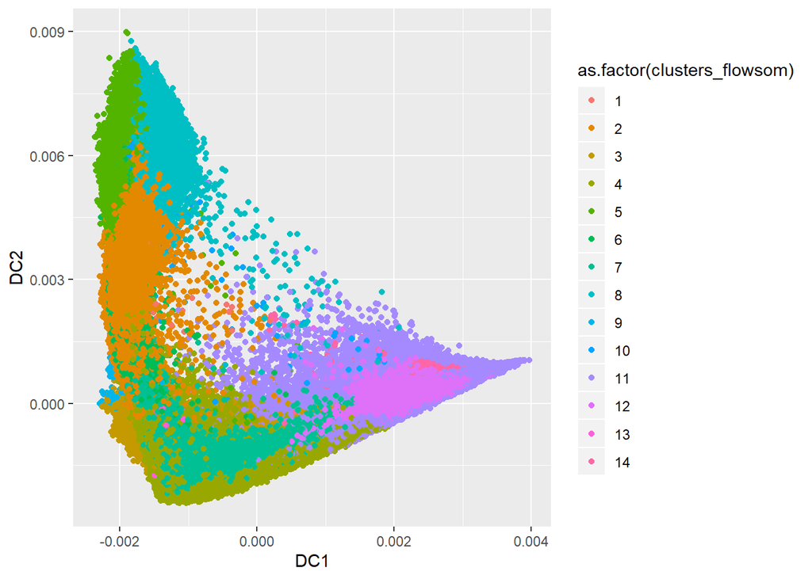

```r
ggplot(dm, aes(x=DC1, y=DC2, color=as.factor(clusters_flowsom)))+geom_point()
```

Add the diffusion components to the data frame

```r
df <- cbind(df, DC1=dm$DC1, DC2=dm$DC2, DC3=dm$DC3)
```

### UMAP

Select the columns which you would like to use for the UMAP n_neighbors controls how UMAP balances local versus global structure in the data min_dist controls how tightly UMAP is allowed to pack points together (low values = clumpier embedding)

```r
umap <- umap(df[,c(7:9, 11, 13:16, 18, 19)], n_neighbors = 30, min_dist=0.001, verbose=TRUE)
```

Plot the umap: each cell is colored by its phenograph cluster

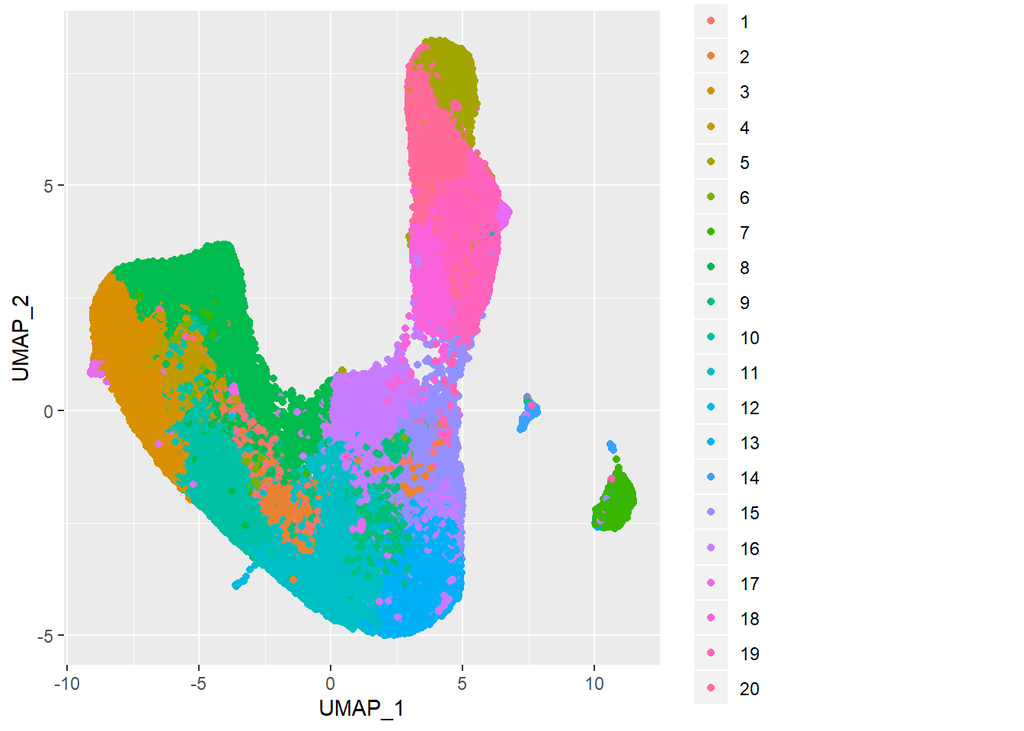

```r
ggplot (as.data.frame(umap), aes(x=V1, y=V2, color=as.factor(clusters_phenograph)))+geom_point()+xlab('UMAP_1')+ylab('UMAP_2')
```

Add the umap coordinates to the data frame

```r
umap<- as.data.frame(umap)
colnames(umap) <- c('umap_1', 'umap_2')
df <- cbind(df,umap)
```

### Pseudotime

Slingshot requires clusters as input for lineage identification. Too many clusters will lead to artificial lineages, therefore we merge clusters and relabel them

If you would like to use other clusters, adjust df$clusters_HSNE and merge the clusters accordingly.

```r
df$merged_HSNE <-gsub("CD4-1$", "Naive", df$clusters_HSNE)
df$merged_HSNE <-gsub("CD4-2$", "Naive", df$merged_HSNE)
df$merged_HSNE <-gsub("CD4-3$", "CD27+ CM", df$merged_HSNE)
df$merged_HSNE <-gsub("CD4-4$", "CD27+ CM", df$merged_HSNE)
df$merged_HSNE <-gsub("CD4-5$", "CD27+ EM", df$merged_HSNE)
df$merged_HSNE <-gsub("CD4-6$", "CD27+ EM", df$merged_HSNE)
df$merged_HSNE <-gsub("CD4-7$", "CD27- EM", df$merged_HSNE)
df$merged_HSNE <-gsub("CD4-8$", "CD27- EM", df$merged_HSNE)
df$merged_HSNE <-gsub("CD4-9$", "EMRA", df$merged_HSNE)
df$merged_HSNE <-gsub("CD4-10$", "EMRA", df$merged_HSNE)
df$merged_HSNE <-gsub("CD4-11$", "CD8dim EMRA", df$merged_HSNE)
df$merged_HSNE <-gsub("CD4-12$", "CD8dim EM", df$merged_HSNE)
df$merged_HSNE <-gsub("CD4-13$", "CD69+CD103- EM", df$merged_HSNE)
df$merged_HSNE <-gsub("CD4-14$", "CD103+ EM", df$merged_HSNE)
```

Create slingshot object

```r
slingshot_object <- SingleCellExperiment(assays = List(norm = as.matrix(t(df))))
```

Add data frame to slingshot object and select the markers you would like to use for the pseudotime calculation

```r
reducedDims(slingshot_object) <- SimpleList(expressiondata = as.matrix(df%>%select(c("CD95", "CD8", "CD27", "CCR7", "CD45RA", "CD49b", "CD69", "CD103", "CD3", "CD4"))))
```

Select the clusters to use for the pseudotime calculation

```r
colData(slingshot_object)$clusters <- df$merged_HSNE
```

Calculate lineages and appoint starting cluster (optionally)

```r
lin <- getLineages(reducedDims(slingshot_object)$expressiondata,colData(slingshot_object)$clusters, start.clus='Naive')
```

Construct smooth curves (to reduce computational time curves can be approximated by a fixed number of points, for instance 100)

```r
curve <- getCurves(lin, approx_points=100)
```

Add pseudotime values to the data frame

```r
df <- cbind(df, as.data.frame(slingPseudotime(curve), row.names=FALSE))
```

Generate table with diffusion map coordinates, pseudotimevalues and cluster assignment

```r
pseudotimevalues <- df%>%select(c(DC1, DC2,clusterID=merged_HSNE, curve1, curve2, curve3))
```

Plot the lineages: cells are colored by pseudotime

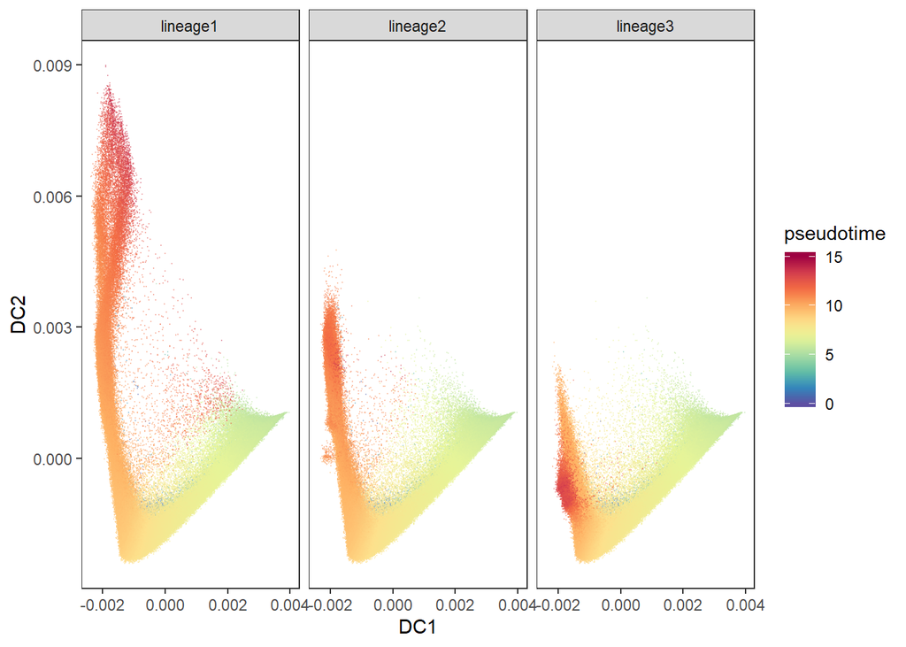

```r
#reshape table
pseudotimevalues <- melt(pseudotimevalues, id.vars=c('clusterID', 'DC1', 'DC2'), variable.name='lineage', value.name = 'pseudotime')

#rename curve to lineage
pseudotimevalues$lineage <- gsub('curve','lineage', pseudotimevalues$lineage)

#exclude cells with NA pseudotimevalues (those cells are not present in all lineages and have NA values for the lineages in which they are absent)
pseudotimevaluesexclNA <- pseudotimevalues%>%filter(pseudotime!='NA')

#generate colorpalette
colors <- colorRampPalette(rev(brewer.pal(11, 'Spectral'))[-6])(100)

#ggplot of each lineage colored by either pseudotime
ggplot(pseudotimevaluesexclNA%>%arrange(pseudotime), aes(x=DC1, y=DC2))+geom_point(aes(color=pseudotime),size=0.1, alpha=0.3) +facet_wrap(~lineage)+scale_color_gradientn(colours=colors)+theme_bw()+theme(panel.grid.major = element_blank(), panel.grid.minor=element_blank())
```

save final df file

```r
write.csv(df, 'df.csv')
```